```python
from google.colab import files
import os
import sys
import shutil
import torch
import torch.nn as nn
import torch.optim as optim
import torch.nn.functional as F
# upload helper.py
uploaded = files.upload()

# print the name of uploaded file
print(uploaded.keys())

# move file to working directory
import shutil
for filename in uploaded.keys():
    shutil.move(filename, './helper.py')  # set name of the file as "helper.py"

# Check working directory
print(os.listdir('.'))
```

Upload widget is only available when the cell has been executed in the current browser session. Please rerun this cell to enable.

```
Saving helper.py to helper.py
dict_keys(['helper.py'])
['.config', 'drive', 'helper.py', 'sample_data']
```

# **This code performs dataset loading and data augmentation operations. The training, validation, and test datasets are prepared using the CelebCariDataset and CelebCariTestDataset classes.**

```python
import torchvision.transforms as transforms
from helper import (CelebCariDataset, CelebCariTestDataset, calculate_accuracy, save_gallery_to_json,
                    create_gallery_embeddings, read_gallery_from_json, encode_embedding, write_predictions_to_json)
import torch
from torch.utils.data import Dataset
from torchvision import transforms
from PIL import Image
import os

from torchvision import transforms

# Transforms
transform = transforms.Compose([
    transforms.Resize((128, 128)),
    transforms.ToTensor(),
])

train_transform = transforms.Compose([
    transforms.Resize((128, 128)),
    transforms.RandomHorizontalFlip(),
    transforms.RandomRotation(20),
    transforms.ColorJitter(brightness=0.2, contrast=0.2, saturation=0.2, hue=0.2),
    transforms.RandomResizedCrop(224, scale=(0.8, 1.0)),
    transforms.ToTensor(),
])

# Dataset path
train_dataset_path = '/content/drive/MyDrive/AnnFinal/train'
test_dataset_path =  '/content/drive/MyDrive/AnnFinal/test'
validation_dataset_path = '/content/drive/MyDrive/AnnFinal/validation'
# Training dataset
train_dataset = CelebCariDataset(train_dataset_path, transform=train_transform)
train_image, person_label, style_label = train_dataset[0]      # Get the first sample from the dataset

# Print the sample details (optional)
print("Image shape:", train_image.shape)
print("Person label:", person_label)
print("Style label:", style_label)

# Validation dataset
validation_dataset = CelebCariDataset(validation_dataset_path, transform=transform)
validation_image, person_label, style_label = validation_dataset[0]

# Print the sample details (optional)
print("Image shape:", validation_image.shape)
print("Person label:", person_label)
print("Style label:", style_label)

# Test dataset
test_dataset = CelebCariTestDataset(test_dataset_path, transform=transform)
test_image, image_path = test_dataset[0]

# DataLoaders
from torch.utils.data import DataLoader

test_loader = DataLoader(test_dataset, batch_size=32, shuffle=False, num_workers=2)
train_loader = DataLoader(train_dataset, batch_size=32, shuffle=True, num_workers=2)
validation_loader = DataLoader(validation_dataset, batch_size=32, shuffle=False, num_workers=2)
```

```
Image shape: torch.Size([3, 224, 224])
Person label: 0
Style label: 0
Image shape: torch.Size([3, 128, 128])
Person label: 0
Style label: 0
```

```python
import torch
import torch.nn.functional as F
from helper import save_gallery_to_json, read_gallery_from_json

def cosine_similarity(embedding1, embedding2):
    return F.cosine_similarity(embedding1.unsqueeze(0), embedding2.unsqueeze(0))

def find_most_similar(embedding, gallery_embeddings):
    max_similarity = -1
    most_similar_person = None
    for person, embeddings in gallery_embeddings.items():
        for gallery_embedding in embeddings:
            similarity = cosine_similarity(embedding, gallery_embedding).item()
            if similarity > max_similarity:
                max_similarity = similarity
                most_similar_person = person
    return most_similar_person, max_similarity

def add_new_person_to_gallery(person_name, embedding, gallery_embeddings, gallery_path):
    if person_name not in gallery_embeddings:
        gallery_embeddings[person_name] = []
    gallery_embeddings[person_name].append(embedding)
    save_gallery_to_json(gallery_embeddings, gallery_path)
```

# **I wrote functions that will be used beforehand**

```python
import torch
import torch.nn as nn
import torch.nn.functional as F
from torchvision import models

class SimpleMultiLabelModel(nn.Module):
    def __init__(self, num_classes_identity, num_classes_style):
        super(SimpleMultiLabelModel, self).__init__()
        self.backbone = models.mobilenet_v2(pretrained=True)
        for param in self.backbone.parameters():
            param.requires_grad = False  # Freeze the backbone
        num_features = self.backbone.classifier[1].in_features
        self.backbone.classifier = nn.Identity()
        self.fc_identity = nn.Sequential(
            nn.Linear(num_features, 256),
            nn.ReLU(),
            nn.Linear(256, num_classes_identity)
        )
        self.fc_style = nn.Sequential(
            nn.Linear(num_features, 256),
            nn.ReLU(),
            nn.Linear(256, num_classes_style)
        )

    def forward(self, x):
        features = self.backbone(x)
        identity_output = self.fc_identity(features)
        style_output = self.fc_style(features)
        return identity_output, style_output, features



num_classes_identity = 20
num_classes_style = 6
model = SimpleMultiLabelModel(num_classes_identity, num_classes_style)
device = torch.device('cuda' if torch.cuda.is_available() else 'cpu')
model = model.to(device)

# Modelin CUDA'da çalıştığını doğrulama
print(next(model.parameters()).is_cuda)  # True
```

```
True
```

# **This code defines a simple multi-label classification model using PyTorch. The model is built on a pre-trained MobileNetV2 backbone, which is frozen to prevent updates during training. The backbone's classifier is replaced with two separate fully connected layers for identity and style classification.**

# **MobileNetV2 is used for this problem because it provides a good balance between accuracy and computational efficiency. Here are the key reasons for its selection:**

- Lightweight Architecture: MobileNetV2 is designed to be computationally efficient with fewer parameters and operations compared to many other deep learning models. This makes it suitable for deployment on resource-constrained devices like mobile phones and embedded systems.
- Pre-trained Weights: Using a pre-trained MobileNetV2 allows leveraging the features learned from a large dataset (like ImageNet), which can improve the model's performance and accelerate convergence, especially useful when labeled data is limited.
- Feature Extraction: MobileNetV2 is effective at extracting useful features from images, which can then be used for multiple tasks (such as identity and style classification in this case).
- Versatility: The architecture is flexible and can be easily adapted for various applications, including multi-label classification tasks as demonstrated by using separate fully connected layers for identity and style outputs.

```python
def train_model(model, train_loader, criterion_person, criterion_style, optimizer, num_epochs):
    model.train()
    for epoch in range(num_epochs):
        running_loss_person = 0.0
        running_loss_style = 0.0
        correct_person = 0
        correct_style = 0
        total = 0

        for inputs, person_labels, style_labels in train_loader:
            inputs, person_labels, style_labels = inputs.to(device), person_labels.to(device), style_labels.to(device)
            optimizer.zero_grad()

            person_outputs, style_outputs,_ = model(inputs)
            loss_person = criterion_person(person_outputs, person_labels)
            loss_style = criterion_style(style_outputs, style_labels)
            loss = loss_person + loss_style
            loss.backward()
            optimizer.step()

            running_loss_person += loss_person.item()
            running_loss_style += loss_style.item()
            _, predicted_person = torch.max(person_outputs, 1)
            _, predicted_style = torch.max(style_outputs, 1)
            correct_person += (predicted_person == person_labels).sum().item()
            correct_style += (predicted_style == style_labels).sum().item()
            total += person_labels.size(0)

        epoch_loss_person = running_loss_person / total
        epoch_loss_style = running_loss_style / total
        epoch_acc_person = correct_person / total
        epoch_acc_style = correct_style / total

        print(f'Epoch [{epoch+1}/{num_epochs}], Person Loss: {epoch_loss_person:.4f}, Style Loss: {epoch_loss_style:.4f}, Person Acc: {epoch_acc_person:.4f}, Style Acc: {epoch_acc_style:.4f}')
```

# **This function train_model is designed to train the SimpleMultiLabelModel for a specified number of epochs. The model is trained on both person and style classifications using separate loss functions for each.**

```python
# Modeli eğit
criterion_person = nn.CrossEntropyLoss()
criterion_style = nn.CrossEntropyLoss()
optimizer = optim.Adam(model.parameters(), lr=0.001)
train_model(model, train_loader, criterion_person, criterion_style, optimizer, 10)
```

```
Epoch [1/10], Person Loss: 0.0577, Style Loss: 0.0417, Person Acc: 0.4309, Style Acc: 0.4922
Epoch [2/10], Person Loss: 0.0319, Style Loss: 0.0269, Person Acc: 0.7034, Style Acc: 0.7029
Epoch [3/10], Person Loss: 0.0237, Style Loss: 0.0219, Person Acc: 0.7701, Style Acc: 0.7681
Epoch [4/10], Person Loss: 0.0195, Style Loss: 0.0191, Person Acc: 0.8059, Style Acc: 0.7824
Epoch [5/10], Person Loss: 0.0177, Style Loss: 0.0190, Person Acc: 0.8172, Style Acc: 0.7794
Epoch [6/10], Person Loss: 0.0161, Style Loss: 0.0170, Person Acc: 0.8417, Style Acc: 0.8069
Epoch [7/10], Person Loss: 0.0163, Style Loss: 0.0171, Person Acc: 0.8407, Style Acc: 0.8010
Epoch [8/10], Person Loss: 0.0137, Style Loss: 0.0169, Person Acc: 0.8564, Style Acc: 0.8088
Epoch [9/10], Person Loss: 0.0137, Style Loss: 0.0162, Person Acc: 0.8569, Style Acc: 0.8172
Epoch [10/10], Person Loss: 0.0130, Style Loss: 0.0162, Person Acc: 0.8667, Style Acc: 0.8083
```

```python
def create_embedding_for_new_person(model, new_data, device):
    model.eval()
    new_data = new_data.to(device)
    with torch.no_grad():
        _, _, person_features = model(new_data)
    return person_features.cpu()

def match_new_person_with_gallery(new_embedding, gallery_embeddings):
    gallery_tensors = torch.stack([torch.mean(torch.stack(embeds), dim=0) for embeds in gallery_embeddings.values()])
    cos_sim = torch.matmul(new_embedding, gallery_tensors.T)
    cos_sim = cos_sim / (torch.norm(new_embedding, dim=1, keepdim=True) * torch.norm(gallery_tensors, dim=1))
    return cos_sim

def add_new_person_to_gallery(new_person_name, new_embedding, gallery_embeddings):
    if new_person_name not in gallery_embeddings:
        gallery_embeddings[new_person_name] = []
    gallery_embeddings[new_person_name].append(new_embedding)
    return gallery_embeddings

def evaluate_model(model, val_dataset, gallery_json_path, device):
    # Load gallery embeddings from JSON file
    loaded_gallery_embeddings = read_gallery_from_json(gallery_json_path)
    print(f"Loaded gallery embeddings: {len(loaded_gallery_embeddings)} persons")

    # Create embeddings for the probe set (validation set)
    probe_embeddings = create_gallery_embeddings(model, val_dataset, device)
    print(f"Created probe embeddings: {len(probe_embeddings)} persons")

    # Cosine similarity for gallery-probe matching
    gallery_tensors = torch.stack([torch.mean(torch.stack(embeds), dim=0) for embeds in loaded_gallery_embeddings.values()])
    probe_tensors = torch.stack([torch.mean(torch.stack(embeds), dim=0) for embeds in probe_embeddings.values()])

    cos_sim = torch.matmul(probe_tensors, gallery_tensors.T)
    cos_sim = cos_sim / (torch.norm(probe_tensors, dim=1, keepdim=True) * torch.norm(gallery_tensors, dim=1))

    # Create a mapping from person names to indices
    person_to_idx = {person: idx for idx, person in enumerate(loaded_gallery_embeddings.keys())}
    idx_to_person = {idx: person for person, idx in person_to_idx.items()}

    # Add an "unknown" category
    unknown_idx = len(person_to_idx)
    idx_to_person[unknown_idx] = "unknown"

    # Convert predicted labels to indices
    predicted_indices = torch.argmax(cos_sim, dim=1).cpu().numpy()

    # True indices based on the probe set
    true_indices = []
    for person_name, embeds in probe_embeddings.items():
        person_name = str(person_name)
        if person_name in person_to_idx:
            person_idx = person_to_idx[person_name]
        else:
            person_idx = unknown_idx
        true_indices.extend([person_idx] * len(embeds))

    if len(predicted_indices) != len(true_indices):
        print(f"Warning: Length mismatch - Predicted: {len(predicted_indices)}, True: {len(true_indices)}")
        min_length = min(len(predicted_indices), len(true_indices))
        predicted_indices = predicted_indices[:min_length]
        true_indices = true_indices[:min_length]

    accuracy = (torch.tensor(predicted_indices) == torch.tensor(true_indices)).float().mean().item()
    print(f'Validation Set Accuracy: {accuracy:.4f}')

    # Visualization
    # Convert indices to person names
    true_labels = [idx_to_person[idx] for idx in true_indices]
    predicted_labels = [idx_to_person[idx] for idx in predicted_indices]

    # Calculate confusion matrix
    cm = confusion_matrix(true_labels, predicted_labels, labels=list(idx_to_person.values()))

    # Plot confusion matrix
    plt.figure(figsize=(10, 8))
    sns.heatmap(cm, annot=True, fmt='d', cmap='Blues', xticklabels=idx_to_person.values(), yticklabels=idx_to_person.values())
    plt.xlabel('Predicted Labels')
    plt.ylabel('True Labels')
    plt.title('Confusion Matrix')
    plt.show()

    # Plot bar chart for true vs predicted labels
    plt.figure(figsize=(12, 6))
    true_count = pd.Series(true_labels).value_counts().sort_index()
    pred_count = pd.Series(predicted_labels).value_counts().sort_index()

    print(f"True label counts: {true_count}")
    print(f"Predicted label counts: {pred_count}")

    if not true_count.empty and not pred_count.empty:
        true_count.plot(kind='bar', alpha=0.5, color='blue', position=0, label='True Labels')
        pred_count.plot(kind='bar', alpha=0.5, color='red', position=1, label='Predicted Labels')

        plt.xlabel('Labels')
        plt.ylabel('Count')
        plt.title('True vs Predicted Labels')
        plt.legend()
        plt.show()
    else:
        print("No data to plot.")

    # Add new persons to the gallery if they are not present
    for person_name, embeds in probe_embeddings.items():
        person_name = str(person_name)
        if person_name not in person_to_idx:
            for embed in embeds:
                gallery_embeddings = add_new_person_to_gallery(person_name, embed, loaded_gallery_embeddings)

    # Save the updated gallery to JSON
    save_gallery_to_json(loaded_gallery_embeddings, gallery_json_path)
    print(f"Updated gallery saved to {gallery_json_path}")
```

# This code snippet provides functions to handle embeddings, match new individuals with a gallery, and evaluate the model. Here’s a concise explanation of each function:

**create_embedding_for_new_person:**

Creates embeddings for new data using the model. Sets the model to evaluation mode and generates person features without gradient calculation.

**match_new_person_with_gallery:**

Matches new embeddings with existing gallery embeddings using cosine similarity. Computes similarity scores between the new embedding and each gallery embedding.

**add_new_person_to_gallery:**

Adds a new person's embedding to the gallery. Appends the new embedding to the list of embeddings for that person.

**evaluate_model:**

Evaluates the model on a validation dataset.Loads gallery embeddings and creates embeddings for the validation set.Calculates cosine similarity between gallery and validation embeddings.Maps person names to indices and calculates accuracy.Plots a confusion matrix and bar charts for true vs. predicted labels. Adds new individuals to the gallery and saves the updated gallery to a JSON file.

```
Loaded gallery embeddings: 12 persons
Created probe embeddings: 4 persons
Warning: Length mismatch - Predicted: 4, True: 240
Validation Set Accuracy: 0.0000
```

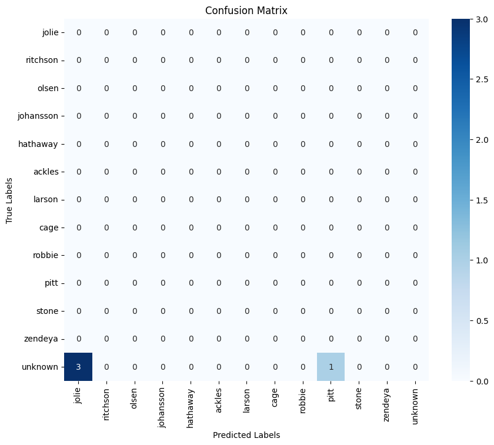

```
True label counts: unknown    4
Name: count, dtype: int64
Predicted label counts: jolie    3
pitt     1
Name: count, dtype: int64
```

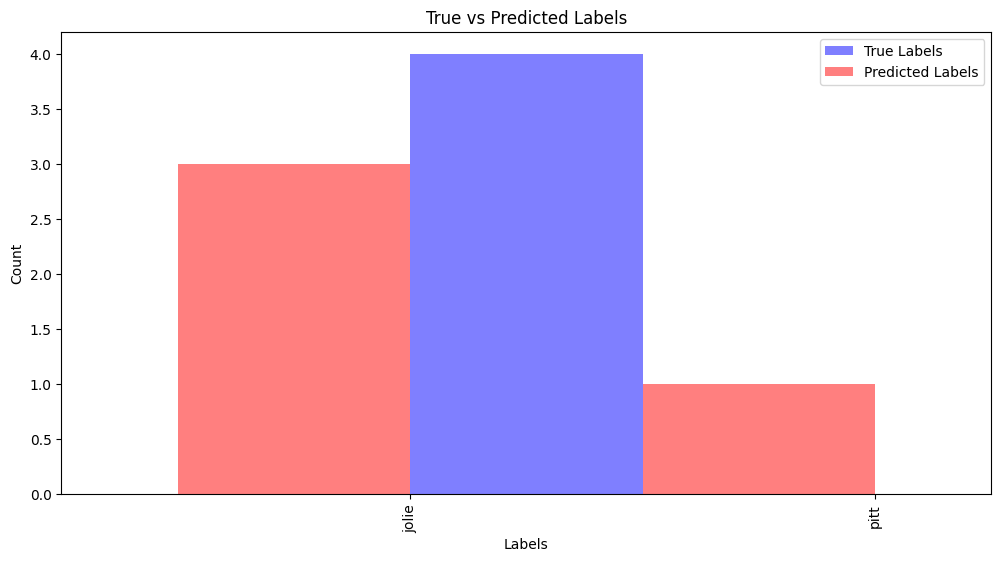

```
Updated gallery saved to gallery.json
```

```python
import matplotlib.pyplot as plt
import pandas as pd
import seaborn as sns
from sklearn.metrics import confusion_matrix
gallery_embeddings = create_gallery_embeddings(model,train_dataset,device)
gallery_path = 'gallery.json'
save_gallery_to_json(gallery_embeddings, gallery_path)
evaluate_model(model, validation_dataset, gallery_path, device)
```

# **Run the code once to detect unseen labels and add them to gallery**

```
Loaded gallery embeddings: 16 persons
Created probe embeddings: 4 persons
Created style embeddings: 6 styles
Total validation images processed: 240
Updated gallery embeddings: 16 persons
Validation Identity Accuracy: 0.9250
Validation Style Accuracy: 0.8583
```

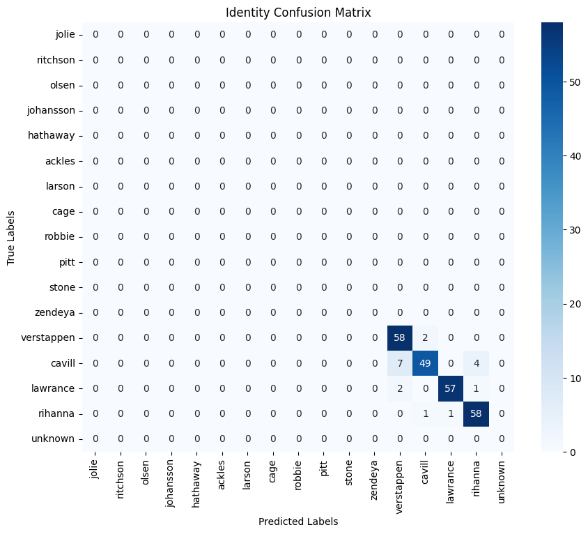

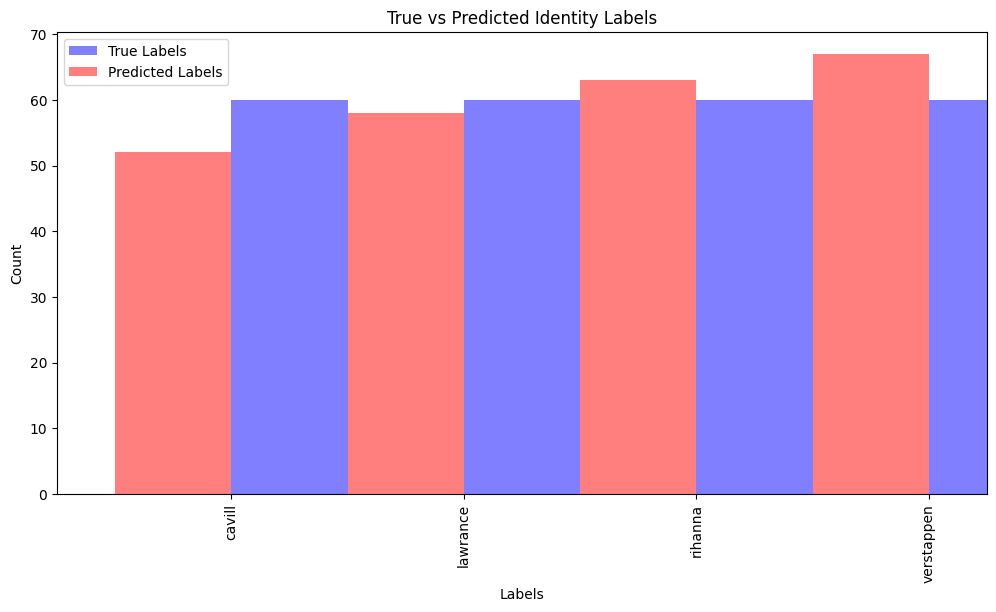

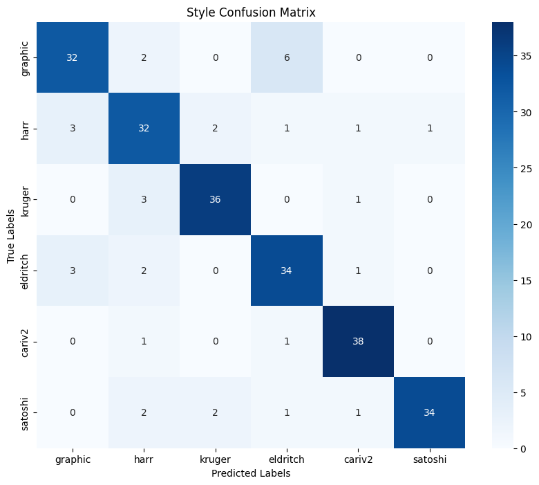

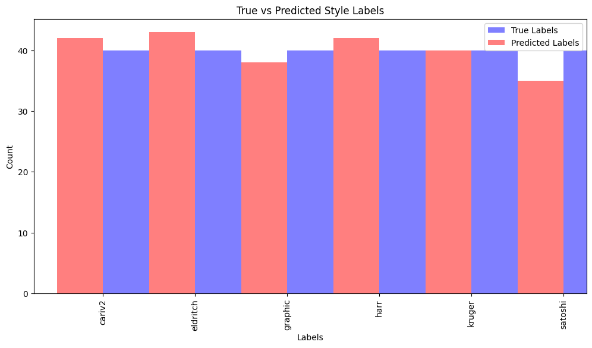

```python
def evaluate_model_and_predict(model, val_dataset, gallery_json_path, device, similarity_threshold=0.5):
    # Load gallery embeddings from JSON file
    loaded_gallery_embeddings = read_gallery_from_json(gallery_json_path)
    print(f"Loaded gallery embeddings: {len(loaded_gallery_embeddings)} persons")

    # Create embeddings for the probe set (validation set)
    model.eval()
    probe_embeddings = {}
    style_embeddings = {}
    probe_labels = []
    style_labels = []
    with torch.no_grad():
        for images, person_labels, style_labels_batch in DataLoader(val_dataset, batch_size=32, shuffle=False):
            images = images.to(device)
            person_labels = person_labels.to(device)
            style_labels_batch = style_labels_batch.to(device)
            person_output, style_output ,embeddings= model(images)
            for embedding, person_label, style_label in zip(embeddings, person_labels, style_labels_batch):
                person_name = val_dataset.index_to_person[person_label.item()]
                style_name = val_dataset.index_to_style[style_label.item()]
                if person_name not in probe_embeddings:
                    probe_embeddings[person_name] = []
                if style_name not in style_embeddings:
                    style_embeddings[style_name] = []
                probe_embeddings[person_name].append(embedding.cpu())
                style_embeddings[style_name].append(embedding.cpu())
                probe_labels.append(person_name)
                style_labels.append(style_name)

    print(f"Created probe embeddings: {len(probe_embeddings)} persons")
    print(f"Created style embeddings: {len(style_embeddings)} styles")
    total_val_images = sum(len(embeds) for embeds in probe_embeddings.values())
    print(f"Total validation images processed: {total_val_images}")

    # Identity evaluation
    all_probe_embeddings = []
    all_probe_labels = []
    for person_name, embeddings in probe_embeddings.items():
        all_probe_embeddings.extend(embeddings)
        all_probe_labels.extend([person_name] * len(embeddings))

    probe_tensors = torch.stack(all_probe_embeddings)
    gallery_tensors = torch.stack([torch.mean(torch.stack(embeds), dim=0) for embeds in loaded_gallery_embeddings.values()])

    cos_sim = torch.matmul(probe_tensors, gallery_tensors.T)
    cos_sim = cos_sim / (torch.norm(probe_tensors, dim=1, keepdim=True) * torch.norm(gallery_tensors, dim=1))

    person_to_idx = {person: idx for idx, person in enumerate(loaded_gallery_embeddings.keys())}
    idx_to_person = {idx: person for person, idx in person_to_idx.items()}
    unknown_idx = len(person_to_idx)
    idx_to_person[unknown_idx] = "unknown"

    predicted_indices = []
    for i, similarities in enumerate(cos_sim):
        max_similarity = torch.max(similarities).item()
        person_name = all_probe_labels[i]
        if max_similarity < similarity_threshold:
            if person_name not in loaded_gallery_embeddings:
                loaded_gallery_embeddings[person_name] = [probe_tensors[i]]
                person_to_idx[person_name] = len(person_to_idx)
                idx_to_person[len(idx_to_person)] = person_name
                predicted_indices.append(person_to_idx[person_name])
        else:
            predicted_indices.append(torch.argmax(similarities).item())

    true_indices = [person_to_idx.get(person_name, unknown_idx) for person_name in all_probe_labels]

    save_gallery_to_json(loaded_gallery_embeddings, gallery_json_path)
    print(f"Updated gallery embeddings: {len(loaded_gallery_embeddings)} persons")

    if len(predicted_indices) != len(true_indices):
        min_length = min(len(predicted_indices), len(true_indices))
        predicted_indices = predicted_indices[:min_length]
        true_indices = true_indices[:min_length]

    accuracy_identity = (torch.tensor(predicted_indices) == torch.tensor(true_indices)).float().mean().item()
    print(f'Validation Identity Accuracy: {accuracy_identity:.4f}')

    # Style evaluation
    all_style_embeddings = []
    all_style_labels = []
    for style_name, embeddings in style_embeddings.items():
        all_style_embeddings.extend(embeddings)
        all_style_labels.extend([style_name] * len(embeddings))

    style_tensors = torch.stack(all_style_embeddings)
    gallery_style_tensors = torch.stack([torch.mean(torch.stack(embeds), dim=0) for embeds in style_embeddings.values()])

    cos_sim_style = torch.matmul(style_tensors, gallery_style_tensors.T)
    cos_sim_style = cos_sim_style / (torch.norm(style_tensors, dim=1, keepdim=True) * torch.norm(gallery_style_tensors, dim=1))

    style_to_idx = {style: idx for idx, style in enumerate(style_embeddings.keys())}
    idx_to_style = {idx: style for style, idx in style_to_idx.items()}

    predicted_style_indices = [torch.argmax(similarities).item() for similarities in cos_sim_style]
    true_style_indices = [style_to_idx[style_name] for style_name in all_style_labels]

    accuracy_style = (torch.tensor(predicted_style_indices) == torch.tensor(true_style_indices)).float().mean().item()
    print(f'Validation Style Accuracy: {accuracy_style:.4f}')

    # Visualization for Identity
    true_labels = [idx_to_person[idx] for idx in true_indices]
    predicted_labels = [idx_to_person[idx] for idx in predicted_indices]

    cm_identity = confusion_matrix(true_labels, predicted_labels, labels=list(idx_to_person.values()))

    plt.figure(figsize=(10, 8))
    sns.heatmap(cm_identity, annot=True, fmt='d', cmap='Blues', xticklabels=idx_to_person.values(), yticklabels=idx_to_person.values())
    plt.xlabel('Predicted Labels')
    plt.ylabel('True Labels')
    plt.title('Identity Confusion Matrix')
    plt.show()

    plt.figure(figsize=(12, 6))
    true_count_identity = pd.Series(true_labels).value_counts().sort_index()
    pred_count_identity = pd.Series(predicted_labels).value_counts().sort_index()
    true_count_identity.plot(kind='bar', alpha=0.5, color='blue', position=0, label='True Labels')
    pred_count_identity.plot(kind='bar', alpha=0.5, color='red', position=1, label='Predicted Labels')
    plt.xlabel('Labels')
    plt.ylabel('Count')
    plt.title('True vs Predicted Identity Labels')
    plt.legend()
    plt.show()

    # Visualization for Style
    true_style_labels = [idx_to_style[idx] for idx in true_style_indices]
    predicted_style_labels = [idx_to_style[idx] for idx in predicted_style_indices]

    cm_style = confusion_matrix(true_style_labels, predicted_style_labels, labels=list(idx_to_style.values()))

    plt.figure(figsize=(10, 8))
    sns.heatmap(cm_style, annot=True, fmt='d', cmap='Blues', xticklabels=idx_to_style.values(), yticklabels=idx_to_style.values())
    plt.xlabel('Predicted Labels')
    plt.ylabel('True Labels')
    plt.title('Style Confusion Matrix')
    plt.show()

    plt.figure(figsize=(12, 6))
    true_count_style = pd.Series(true_style_labels).value_counts().sort_index()
    pred_count_style = pd.Series(predicted_style_labels).value_counts().sort_index()
    true_count_style.plot(kind='bar', alpha=0.5, color='blue', position=0, label='True Labels')
    pred_count_style.plot(kind='bar', alpha=0.5, color='red', position=1, label='Predicted Labels')
    plt.xlabel('Labels')
    plt.ylabel('Count')
    plt.title('True vs Predicted Style Labels')
    plt.legend()
    plt.show()

evaluate_model_and_predict(model, validation_dataset, gallery_path, device)
```

```python
import torch
from torch.utils.data import DataLoader
from helper import read_gallery_from_json, write_predictions_to_json, encode_embedding

def evaluate_test_set_write(model, test_dataset, gallery_json_path, device, output_json_path, similarity_threshold=0.5):
    """
    Evaluate the model on the test set and write predictions to a JSON file.

    Args:
    - model: The trained model to be evaluated.
    - test_dataset: The test dataset.
    - gallery_json_path: Path to the gallery embeddings JSON file.
    - device: Device to run the model on (e.g., 'cuda' or 'cpu').
    - output_json_path: Path to the output JSON file for predictions.
    - similarity_threshold: Threshold for similarity to consider a match.

    Returns:
    - predictions: List of tuples containing filename, embedding, and style.
    """
    # Load gallery embeddings from JSON file
    loaded_gallery_embeddings = read_gallery_from_json(gallery_json_path)
    print(f"Loaded gallery embeddings: {len(loaded_gallery_embeddings)} persons")

    # Create embeddings for the probe set (test set)
    model.eval()
    probe_embeddings = []
    filenames = []
    style_outputs_list = []

    with torch.no_grad():
        for images, paths in DataLoader(test_dataset, batch_size=32, shuffle=False):
            images = images.to(device)
            _, style_outputs,embeddings = model(images)
            for embedding, path, style_output in zip(embeddings, paths, style_outputs):
                probe_embeddings.append(embedding.cpu())
                filenames.append(path)
                style_outputs_list.append(style_output.cpu())

    print(f"Created probe embeddings for {len(filenames)} images")

    # Generate predictions
    predictions = []
    probe_tensors = torch.stack(probe_embeddings)
    gallery_tensors = torch.stack([torch.mean(torch.stack(embeds), dim=0) for embeds in loaded_gallery_embeddings.values()])

    cos_sim = torch.matmul(probe_tensors, gallery_tensors.T)
    cos_sim = cos_sim / (torch.norm(probe_tensors, dim=1, keepdim=True) * torch.norm(gallery_tensors, dim=1))

    person_to_idx = {person: idx for idx, person in enumerate(loaded_gallery_embeddings.keys())}
    idx_to_person = {idx: person for person, idx in person_to_idx.items()}
    unknown_idx = len(person_to_idx)
    idx_to_person[unknown_idx] = "unknown"

    for i, similarities in enumerate(cos_sim):
        max_similarity = torch.max(similarities).item()
        if max_similarity < similarity_threshold:
            predicted_person = "unknown"
        else:
            predicted_person = idx_to_person[torch.argmax(similarities).item()]
        predicted_style = torch.argmax(style_outputs_list[i]).item()  # Predicting style

        predictions.append((filenames[i], probe_tensors[i], predicted_style))

    write_predictions_to_json(predictions, output_json_path)

    return predictions


prediction_path = 'predictions.json'
evaluate_test_set_write(model, test_dataset, gallery_path, device,prediction_path)
```

## **Write the predictions to a json file.**

# **References**

• Sandler, Mark, et al. "MobileNetV2: Inverted Residuals and Linear Bottlenecks." Proceedings of the IEEE Conference on Computer Vision and Pattern Recognition. 2018.

• Torchvision: "Pre-trained models in Torchvision." GitHub repository.

•https://online.yasar.edu.tr/mod/assign/view.php?id=82270

•My classmates